# Problem set: Event count models

Silje Synnøve Lyder Hermansen

2023-03-30

> Estimating the base-line count models involve much less recoding than the logistic regressions. however, the poisson model assumes equidispersion – the conditinoal mean is the same as the variance. These exercices are intended to help you understand the results and assess the model.

We will be working on the number of legislative proposals (“reports”) that Member of the European Parliament have handled over the course of a legislative term.

### Estimate a poisson model and calculate the overdispersion

When in presence of count data, we are interested in how the residuals are dispersed (spread out), since this would bias our results and provide us with overly optimistic assessments of the error.

1. Estimate a poisson model and report the results in a table.
2. Calculate and plot the standardized residuals ($z_i$) of the model (y axis) against the fitted/predicted values (x axis).

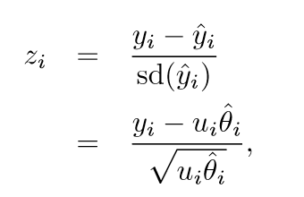

3. Draw a horizontal line att y = 0 and two additional horizontal lines at $\pm 2$ (or 1.96). The standardized residuals are supposed to be in this bound. How does it look? Can you explain the high z values?
4. Use the instructions in Gelman and Hill (2007), p 114 to calculate a measure of overdispersion.

This implies i) calculating the sum of squared standardized residuals ($\Sigma z_i^2$; `sum(z^2)`). And ii) calculate their expexted value ($n-k$; ``nrow(df) - (length(mod1.pois$coefficients-1)`). Now you can iii) compar them as a ratio.

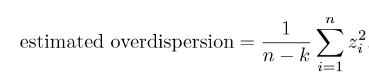

Any value over 2 is considered large.

### Exercise 2: Create an effect plot

Create an effect plot where you illustrate the effect of ideology on influence. Remember that the poisson backtransformation only implies taking the exponent!

# Literature

Gelman, Andrew, and Jennifer Hill. 2007. *Data Analysis Using Regression and Multilevel/Hierarchical Models*. Analytical Methods for Social Research. Cambridge ; New York: Cambridge University Press.